# Reglas de asociación para Chinook — Aplicación de CRISP-DM

Este cuaderno aplica de forma parcial la metodología **CRISP-DM** (Cross Industry Standard Process for Data Mining) sobre los datos de ventas de Chinook Digital Media Store. El modelo de minería seleccionado es el de **reglas de asociación** (análisis de canasta de mercado), y cada sección del documento corresponde explícitamente a una de las fases de CRISP-DM: comprensión del negocio, comprensión de los datos, preparación de los datos, modelado, evaluación y despliegue.

# Fase 1 — Comprensión del negocio

## Contexto

Chinook es una tienda de música digital cuyo objetivo estratégico, según el anteproyecto, es **maximizar los ingresos por ventas recurrentes a través de la retención y fidelización de clientes de alto valor** (Objetivo de Negocio 2). Dentro de ese objetivo, el presente modelo de minería da soporte directo al **Criterio de éxito 2.2**: generar la base para que marketing despliegue campañas de promociones personalizadas (por ejemplo, cupones por géneros preferidos), buscando un incremento del ticket promedio de compra.

## Problema de negocio que resuelve el modelo

A diferencia de los requerimientos descriptivos del Data Warehouse (rotación de catálogo, clientes VIP), aquí el problema es de **cross-selling y recomendación**: descubrir qué géneros musicales tienden a comprarse juntos en una misma factura. Las reglas de la forma `{género A} => {género B}` permiten construir recomendaciones del tipo “los clientes que compraron esto también compraron…” y diseñar cupones cruzados.

## Objetivos de minería de datos

- Descubrir reglas de asociación entre géneros co-comprados dentro de una misma transacción (factura).
- Obtener un conjunto **conciso e interpretable** de reglas, libre de redundancias, accionable por el equipo de marketing.

## Criterios de éxito de la minería

- Reglas con **confianza superior a 0.85** y **lift mayor que 1** (que evidencie asociación real y no coincidencia por azar).
- Resultado exportable para su consumo en el dashboard y en campañas.

## Recursos

- Datos extraídos del **Data Warehouse** propio (hechos de ventas y la dimensión de producto con su género), no de la base transaccional cruda.
- Lenguaje R con los paquetes `arules` y `arulesViz`.

# Fase 2 — Comprensión de los datos

## Carga de librerías y lectura de datos

```r
# install.packages("plyr")
# install.packages("arules")
# install.packages("arulesViz")
# install.packages("tidyverse")


library(plyr)
library(arules)
library(arulesViz)
library(tidyverse)
# library(dplyr)
```

El insumo es un archivo CSV exportado desde el Data Warehouse, con el detalle de género por factura y fecha (`id_factura`, `genero_actual`, `llave_fecha`, entre otros).

```r
datos <- read.csv("data-1782396576577.csv", sep = ",", dec = ".")


# install.packages("readxl")
# library(readxl)
# datos<- read_excel('Online Retail.xlsx')

head(datos, 10)
```

```
##    id_factura cantidad_vendida precio_unitario_historico ingresos_linea
## 1           1                1                      0.99           0.99
## 2           1                1                      0.99           0.99
## 3           2                1                      0.99           0.99
## 4           2                1                      0.99           0.99
## 5           2                1                      0.99           0.99
## 6           2                1                      0.99           0.99
## 7           3                1                      0.99           0.99
## 8           3                1                      0.99           0.99
## 9           3                1                      0.99           0.99
## 10          3                1                      0.99           0.99
##    llave_fecha id_track_original        nombre_cancion
## 1     20210101                 2     Balls to the Wall
## 2     20210101                 4     Restless and Wild
## 3     20210102                 6 Put The Finger On You
```

[output cut: 29 more lines]

```r
head(datos)
```

```
##   id_factura cantidad_vendida precio_unitario_historico ingresos_linea
## 1          1                1                      0.99           0.99
## 2          1                1                      0.99           0.99
## 3          2                1                      0.99           0.99
## 4          2                1                      0.99           0.99
## 5          2                1                      0.99           0.99
## 6          2                1                      0.99           0.99
##   llave_fecha id_track_original        nombre_cancion
## 1    20210101                 2     Balls to the Wall
## 2    20210101                 4     Restless and Wild
## 3    20210102                 6 Put The Finger On You
## 4    20210102                 8      Inject The Venom
## 5    20210102                10            Evil Walks
## 6    20210102                12    Breaking The Rules
##                                   album artista genero_actual genero_anterior
## 1                     Balls to the Wall  Accept          Rock              NA
## 2                     Restless and Wild  Accept          Rock              NA
## 3 For Those About To Rock We Salute You   AC/DC          Rock              NA
## 4 For Those About To Rock We Salute You   AC/DC          Rock              NA
## 5 For Those About To Rock We Salute You   AC/DC          Rock              NA
## 6 For Those About To Rock We Salute You   AC/DC          Rock              NA
##   registro_activo
## 1            TRUE
## 2            TRUE
## 3            TRUE
## 4            TRUE
## 5            TRUE
## 6            TRUE
```

```r
tail(datos)
```

```
##      id_factura cantidad_vendida precio_unitario_historico ingresos_linea
## 2235        411                1                      0.99           0.99
## 2236        411                1                      0.99           0.99
## 2237        411                1                      0.99           0.99
## 2238        411                1                      0.99           0.99
## 2239        411                1                      0.99           0.99
## 2240        412                1                      1.99           1.99
##      llave_fecha id_track_original
## 2235    20251214              3127
## 2236    20251214              3136
## 2237    20251214              3145
## 2238    20251214              3154
## 2239    20251214              3163
## 2240    20251222              3177
##                                           nombre_cancion               album
## 2235                            Um Homem Chamado Alfredo  Vinicius De Moraes
## 2236                                    Looking For Love       Greatest Hits
## 2237                                     Sweet Lady Luck       Greatest Hits
## 2238 Feirinha da Pavuna/Luz do Repente/Baga�o da Laranja    Ao Vivo [IMPORT]
## 2239                                    Samba pras mo�as    Ao Vivo [IMPORT]
## 2240                                            Hot Girl The Office Season 1
##                 artista genero_actual genero_anterior registro_activo
## 2235 Vin�cius De Moraes         Latin              NA            TRUE
## 2236      Lenny Kravitz         Metal              NA            TRUE
## 2237      Lenny Kravitz         Metal              NA            TRUE
## 2238     Zeca Pagodinho         Latin              NA            TRUE
## 2239     Zeca Pagodinho         Latin              NA            TRUE
## 2240         The Office      TV Shows              NA            TRUE
```

```r
str(datos)
```

```
## 'data.frame':    2240 obs. of  12 variables:
##  $ id_factura               : int  1 1 2 2 2 2 3 3 3 3 ...
##  $ cantidad_vendida         : int  1 1 1 1 1 1 1 1 1 1 ...
##  $ precio_unitario_historico: num  0.99 0.99 0.99 0.99 0.99 0.99 0.99 0.99 0.99 0.99 ...
##  $ ingresos_linea           : num  0.99 0.99 0.99 0.99 0.99 0.99 0.99 0.99 0.99 0.99 ...
##  $ llave_fecha              : int  20210101 20210101 20210102 20210102 20210102 20210102 20210103 20210103 20210103 20210103 ...
##  $ id_track_original        : int  2 4 6 8 10 12 16 20 24 28 ...
##  $ nombre_cancion           : chr  "Balls to the Wall" "Restless and Wild" "Put The Finger On You" "Inject The Venom" ...
##  $ album                    : chr  "Balls to the Wall" "Restless and Wild" "For Those About To Rock We Salute You" "For Those About To Rock We Salute You" ...
##  $ artista                  : chr  "Accept" "Accept" "AC/DC" "AC/DC" ...
##  $ genero_actual            : chr  "Rock" "Rock" "Rock" "Rock" ...
##  $ genero_anterior          : logi  NA NA NA NA NA NA ...
##  $ registro_activo          : logi  TRUE TRUE TRUE TRUE TRUE TRUE ...
```

```r
summary(datos)
```

```
##    id_factura    cantidad_vendida precio_unitario_historico ingresos_linea
##  Min.   :  1.0   Min.   :1        Min.   :0.99              Min.   :0.99
##  1st Qu.:103.0   1st Qu.:1        1st Qu.:0.99              1st Qu.:0.99
##  Median :207.0   Median :1        Median :0.99              Median :0.99
##  Mean   :206.9   Mean   :1        Mean   :1.04              Mean   :1.04
##  3rd Qu.:311.0   3rd Qu.:1        3rd Qu.:0.99              3rd Qu.:0.99
##  Max.   :412.0   Max.   :1        Max.   :1.99              Max.   :1.99
##   llave_fecha       id_track_original   nombre_cancion       album
##  Min.   :20210101   Min.   :   1      Length   :2240   Length   :2240
##  1st Qu.:20220321   1st Qu.: 874      N.unique :1887   N.unique : 304
##  Median :20230624   Median :1708      N.blank  :   0   N.blank  :   0
##  Mean   :20230521   Mean   :1718      Min.nchar:   1   Min.nchar:   2
##  3rd Qu.:20240928   3rd Qu.:2560      Max.nchar: 120   Max.nchar:  93
##  Max.   :20251222   Max.   :3500
##       artista       genero_actual  genero_anterior registro_activo
##  Length   :2240   Length   :2240   Mode:logical    Mode:logical
##  N.unique : 165   N.unique :  24   NAs :2240       TRUE:2240
##  N.blank  :   0   N.blank  :   0
##  Min.nchar:   2   Min.nchar:   3
##  Max.nchar:  83   Max.nchar:  18
##
```

## Revisión de calidad: valores nulos

Antes de transformar los datos se inspecciona la presencia de valores faltantes por fila y por columna, para dimensionar la limpieza necesaria en la siguiente fase.

```r
sum(is.na(datos))
```

```
## [1] 2240
```

```r
colSums(is.na(datos))
```

```
##                id_factura          cantidad_vendida precio_unitario_historico
##                         0                         0                         0
##            ingresos_linea               llave_fecha         id_track_original
##                         0                         0                         0
##            nombre_cancion                     album                   artista
##                         0                         0                         0
##             genero_actual           genero_anterior           registro_activo
##                         0                      2240                         0
```

```r
apply(X = is.na(datos), MARGIN = 1, FUN = sum) # Fila
```

[output not shown]

[output cut: 46 more lines]

```r
apply(X = is.na(datos), MARGIN = 2, FUN = sum) # Columna
```

```
##                id_factura          cantidad_vendida precio_unitario_historico
##                         0                         0                         0
##            ingresos_linea               llave_fecha         id_track_original
##                         0                         0                         0
##            nombre_cancion                     album                   artista
##                         0                         0                         0
##             genero_actual           genero_anterior           registro_activo
##                         0                      2240                         0
```

# Fase 3 — Preparación de los datos

> CRISP-DM es iterativo: la comprensión y la preparación de los datos se retroalimentan. En esta fase se limpia el conjunto, se construye el formato transaccional y se vuelve a explorar el dataset ya preparado para confirmar que está listo para el modelado.

## Limpieza y conversión de tipos

Se elimina la columna `genero_anterior` (no se usa en el modelo), se descartan los registros con nulos y se convierte `llave_fecha` a tipo `Date`.

```r
# rowSums(is.na(datos))
datos$count_na_x1tox3 <- rowSums(is.na(datos))

datos$genero_anterior <- NULL
datosCompletos <- na.omit(datos)

# se convierte la fecha a tipo Date
datosCompletos$Date <- as.Date(as.character(datosCompletos$llave_fecha), format = "%Y%m%d")
summary(datosCompletos)
```

```
##    id_factura    cantidad_vendida precio_unitario_historico ingresos_linea
##  Min.   :  1.0   Min.   :1        Min.   :0.99              Min.   :0.99
##  1st Qu.:103.0   1st Qu.:1        1st Qu.:0.99              1st Qu.:0.99
##  Median :207.0   Median :1        Median :0.99              Median :0.99
##  Mean   :206.9   Mean   :1        Mean   :1.04              Mean   :1.04
##  3rd Qu.:311.0   3rd Qu.:1        3rd Qu.:0.99              3rd Qu.:0.99
##  Max.   :412.0   Max.   :1        Max.   :1.99              Max.   :1.99
##   llave_fecha       id_track_original   nombre_cancion       album
##  Min.   :20210101   Min.   :   1      Length   :2240   Length   :2240
##  1st Qu.:20220321   1st Qu.: 874      N.unique :1887   N.unique : 304
##  Median :20230624   Median :1708      N.blank  :   0   N.blank  :   0
##  Mean   :20230521   Mean   :1718      Min.nchar:   1   Min.nchar:   2
##  3rd Qu.:20240928   3rd Qu.:2560      Max.nchar: 120   Max.nchar:  93
##  Max.   :20251222   Max.   :3500
##       artista       genero_actual  registro_activo count_na_x1tox3
##  Length   :2240   Length   :2240   Mode:logical    Min.   :1
##  N.unique : 165   N.unique :  24   TRUE:2240       1st Qu.:1
##  N.blank  :   0   N.blank  :   0                   Median :1
##  Min.nchar:   2   Min.nchar:   3                   Mean   :1
##  Max.nchar:  83   Max.nchar:  18                   3rd Qu.:1
##                                                    Max.   :1
##       Date
##  Min.   :2021-01-01
##  1st Qu.:2022-03-21
##  Median :2023-06-24
##  Mean   :2023-06-25
##  3rd Qu.:2024-09-28
##  Max.   :2025-12-22
```

```r
head(datosCompletos)
```

```
##   id_factura cantidad_vendida precio_unitario_historico ingresos_linea
## 1          1                1                      0.99           0.99
## 2          1                1                      0.99           0.99
## 3          2                1                      0.99           0.99
## 4          2                1                      0.99           0.99
## 5          2                1                      0.99           0.99
## 6          2                1                      0.99           0.99
##   llave_fecha id_track_original        nombre_cancion
## 1    20210101                 2     Balls to the Wall
## 2    20210101                 4     Restless and Wild
## 3    20210102                 6 Put The Finger On You
## 4    20210102                 8      Inject The Venom
## 5    20210102                10            Evil Walks
## 6    20210102                12    Breaking The Rules
##                                   album artista genero_actual registro_activo
## 1                     Balls to the Wall  Accept          Rock            TRUE
## 2                     Restless and Wild  Accept          Rock            TRUE
## 3 For Those About To Rock We Salute You   AC/DC          Rock            TRUE
## 4 For Those About To Rock We Salute You   AC/DC          Rock            TRUE
## 5 For Those About To Rock We Salute You   AC/DC          Rock            TRUE
## 6 For Those About To Rock We Salute You   AC/DC          Rock            TRUE
##   count_na_x1tox3       Date
## 1               1 2021-01-01
## 2               1 2021-01-01
## 3               1 2021-01-02
## 4               1 2021-01-02
## 5               1 2021-01-02
## 6               1 2021-01-02
```

## Conversión a formato transacción

Se agrupan las compras por factura y fecha, concatenando los géneros adquiridos en cada transacción, y se guarda el resultado en un CSV con formato de canasta (`basket`).

```r
# se agrupan las transacciones con igual InvoiceNo y Date
# luego se concatena con una coma

transacciones <- ddply(
  datosCompletos, c("id_factura", "Date"),
  function(dataf) paste(dataf$genero_actual, collapse = ",")
)

# se descartan la fecha y el # de facturas para las reglas de asociación

transacciones$id_factura <- NULL
transacciones$Date <- NULL

# se renombra la columna restante como items

colnames(transacciones) <- c("items")

# se guardan los datos como archivo csv en formato transaccion
write.table(transacciones, "transaccionesOR.csv", quote = FALSE, row.names = FALSE, col.names = FALSE)
```

## Lectura del archivo en formato transacción

```r
library(arules)
transacc <- read.transactions("transaccionesOR.csv", sep = ",", format = "basket", quote = "", rm.duplicates = 1)
```

```
## distribution of transactions with duplicates:
## items
##   1   2   3   4   5   6   7   8   9  10  11  12
## 108  11  54  30  33  21  24  13  17  19   8   6
```

```r
# transacc<- read.transactions('transaccionesOR.csv', sep=',', format = 'basket')
```

## Exploración del conjunto transaccional preparado

Se inspecciona la estructura de las transacciones generadas para validar que la preparación fue correcta.

```r
summary(transacc)
```

```
## transactions as itemMatrix in sparse format with
##  412 rows (elements/itemsets/transactions) and
##  24 columns (items) and a density of 0.07706311
##
## most frequent items:
##               Rock              Latin              Metal Alternative & Punk
##                216                117                 96                 93
##               Jazz            (Other)
##                 41                199
##
## element (itemset/transaction) length distribution:
## sizes
##   1   2   3   4   5   6   7
## 246  76  35  29  17   5   4
##
##    Min. 1st Qu.  Median    Mean 3rd Qu.    Max.
##    1.00    1.00    1.00    1.85    2.00    7.00
##
## includes extended item information - examples:
##               labels
## 1        Alternative
## 2 Alternative & Punk
## 3              Blues
```

```r
inspect(transacc[1:5])
```

```
##     items
## [1] {Rock}
## [2] {Rock}
## [3] {Rock}
## [4] {Jazz,
##      Metal,
##      Rock}
## [5] {Alternative & Punk,
##      Blues,
##      Jazz,
##      Latin,
##      Metal,
##      Rock And Roll}
```

```r
# install.packages("tidyverse")
# como alternativa install.packages("tibble")
# aplicar el paquete tidyverse
df_transacciones <- as(transacc, Class = "data.frame")
# Para que el tamaño de la tabla se ajuste mejor, se convierte el dataframe a tibble
as.tibble(df_transacciones) %>% head(10)
```

```
## # A tibble: 10 × 1
##    items
##    <chr>
##  1 {Rock}
##  2 {Rock}
##  3 {Rock}
##  4 {Jazz,Metal,Rock}
##  5 {Alternative & Punk,Blues,Jazz,Latin,Metal,Rock And Roll}
##  6 {Latin}
##  7 {Latin}
##  8 {Latin}
##  9 {Latin}
## 10 {Latin}
```

Tamaño de cada transacción (cantidad de géneros por factura):

```r
tamanyos <- size(transacc)
summary(tamanyos)
```

```
##    Min. 1st Qu.  Median    Mean 3rd Qu.    Max.
##    1.00    1.00    1.00    1.85    2.00    7.00
```

```r
quantile(tamanyos, probs = seq(0, 1, 0.1))
```

```
##   0%  10%  20%  30%  40%  50%  60%  70%  80%  90% 100%
##    1    1    1    1    1    1    2    2    3    4    7
```

Ítems (géneros) más frecuentes, que ayudan a anticipar qué productos dominarán las reglas:

```r
frecuentes <- eclat(transacc, parameter = list(supp = 0.001, maxlen = 10))
```

```
## Eclat
##
## parameter specification:
##  tidLists support minlen maxlen            target  ext
##     FALSE   0.001      1     10 frequent itemsets TRUE
##
## algorithmic control:
##  sparse sort verbose
##       7   -2    TRUE
##
## Absolute minimum support count: 0
##
## create itemset ...
## set transactions ...[24 item(s), 412 transaction(s)] done [0.00s].
## sorting and recoding items ... [24 item(s)] done [0.00s].
## creating sparse bit matrix ... [24 row(s), 412 column(s)] done [0.00s].
## writing  ... [745 set(s)] done [0.00s].
## Creating S4 object  ... done [0.00s].
```

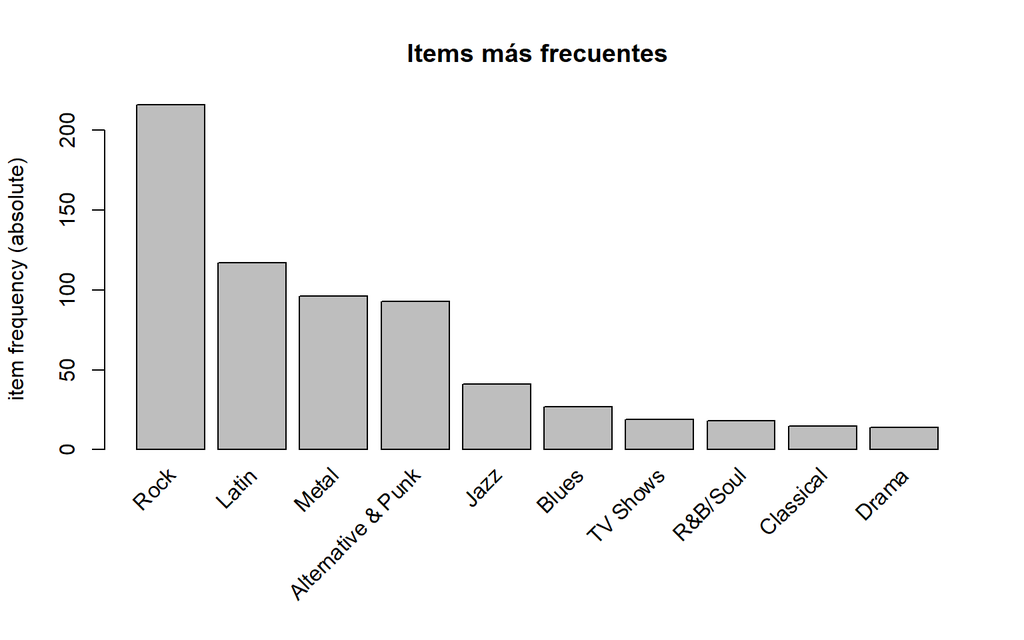

```r
itemFrequencyPlot(transacc, topN = 10, type = "absolute", main = "Items más frecuentes")
```

# Fase 4 — Modelado

El algoritmo seleccionado es **Apriori**, apropiado para descubrir reglas de asociación. Se parte de un soporte mínimo de 0.001 y una confianza mínima de 0.8.

## Generación inicial de reglas

```r
reglas <- apriori(transacc, parameter = list(supp = 0.001, conf = 0.8, maxlen = 10))
```

```
## Apriori
##
## Parameter specification:
##  confidence minval smax arem  aval originalSupport maxtime support minlen
##         0.8    0.1    1 none FALSE            TRUE       5   0.001      1
##  maxlen target  ext
##      10  rules TRUE
##
## Algorithmic control:
##  filter tree heap memopt load sort verbose
##     0.1 TRUE TRUE  FALSE TRUE    2    TRUE
##
## Absolute minimum support count: 0
##
## set item appearances ...[0 item(s)] done [0.00s].
## set transactions ...[24 item(s), 412 transaction(s)] done [0.00s].
## sorting and recoding items ... [24 item(s)] done [0.00s].
## creating transaction tree ... done [0.00s].
## checking subsets of size 1 2 3 4 5 6 7 done [0.01s].
## writing ... [1374 rule(s)] done [0.00s].
## creating S4 object  ... done [0.00s].
```

```r
inspect(reglas[1:10])
```

```
##      lhs                  rhs                  support     confidence
## [1]  {Science Fiction} => {TV Shows}           0.009708738 1.0
## [2]  {Heavy Metal}     => {Blues}              0.009708738 0.8
## [3]  {Heavy Metal}     => {Metal}              0.012135922 1.0
## [4]  {Heavy Metal}     => {Rock}               0.012135922 1.0
## [5]  {Rock And Roll}   => {Jazz}               0.009708738 1.0
## [6]  {Rock And Roll}   => {Alternative & Punk} 0.009708738 1.0
## [7]  {Rock And Roll}   => {Metal}              0.009708738 1.0
## [8]  {Easy Listening}  => {Soundtrack}         0.009708738 1.0
## [9]  {Easy Listening}  => {Alternative & Punk} 0.009708738 1.0
## [10] {Easy Listening}  => {Latin}              0.009708738 1.0
##      coverage    lift      count
## [1]  0.009708738 21.684211 4
## [2]  0.012135922 12.207407 4
## [3]  0.012135922  4.291667 5
## [4]  0.012135922  1.907407 5
## [5]  0.009708738 10.048780 4
## [6]  0.009708738  4.430108 4
## [7]  0.009708738  4.291667 4
## [8]  0.009708738 34.333333 4
## [9]  0.009708738  4.430108 4
## [10] 0.009708738  3.521368 4
```

## Refinamiento: reducir el número de reglas

Se reduce la longitud máxima de las reglas para obtener un conjunto más manejable.

```r
# Generar menos reglas
reglas <- apriori(transacc, parameter = list(supp = 0.001, conf = 0.8, maxlen = 4))
```

[output not shown]

```
##  done [0.00s].
## writing ... [766 rule(s)] done [0.00s].
## creating S4 object  ... done [0.00s].
```

```r
inspect(reglas[1:10])
```

```
##      lhs                  rhs                  support     confidence
## [1]  {Science Fiction} => {TV Shows}           0.009708738 1.0
## [2]  {Heavy Metal}     => {Blues}              0.009708738 0.8
## [3]  {Heavy Metal}     => {Metal}              0.012135922 1.0
## [4]  {Heavy Metal}     => {Rock}               0.012135922 1.0
## [5]  {Rock And Roll}   => {Jazz}               0.009708738 1.0
## [6]  {Rock And Roll}   => {Alternative & Punk} 0.009708738 1.0
## [7]  {Rock And Roll}   => {Metal}              0.009708738 1.0
## [8]  {Easy Listening}  => {Soundtrack}         0.009708738 1.0
## [9]  {Easy Listening}  => {Alternative & Punk} 0.009708738 1.0
## [10] {Easy Listening}  => {Latin}              0.009708738 1.0
##      coverage    lift      count
## [1]  0.009708738 21.684211 4
## [2]  0.012135922 12.207407 4
## [3]  0.012135922  4.291667 5
## [4]  0.012135922  1.907407 5
## [5]  0.009708738 10.048780 4
## [6]  0.009708738  4.430108 4
## [7]  0.009708738  4.291667 4
## [8]  0.009708738 34.333333 4
## [9]  0.009708738  4.430108 4
## [10] 0.009708738  3.521368 4
```

## Eliminación de reglas redundantes

Se descartan las reglas que son subconjuntos de otras, para quedarse con un conjunto conciso y significativo.

```r
# eliminar reglas que son subconjuntos de otras
subconjuntos <- which(colSums(is.subset(reglas, reglas)) > 1)

reglasFinal <- reglas[-subconjuntos]
inspect(reglasFinal[1:10])
```

```
##      lhs                  rhs                  support     confidence
## [1]  {Science Fiction} => {TV Shows}           0.009708738 1.0
## [2]  {Heavy Metal}     => {Blues}              0.009708738 0.8
## [3]  {Heavy Metal}     => {Metal}              0.012135922 1.0
## [4]  {Heavy Metal}     => {Rock}               0.012135922 1.0
## [5]  {Rock And Roll}   => {Jazz}               0.009708738 1.0
## [6]  {Rock And Roll}   => {Alternative & Punk} 0.009708738 1.0
## [7]  {Rock And Roll}   => {Metal}              0.009708738 1.0
## [8]  {Easy Listening}  => {Soundtrack}         0.009708738 1.0
## [9]  {Easy Listening}  => {Alternative & Punk} 0.009708738 1.0
## [10] {Easy Listening}  => {Latin}              0.009708738 1.0
##      coverage    lift      count
## [1]  0.009708738 21.684211 4
## [2]  0.012135922 12.207407 4
## [3]  0.012135922  4.291667 5
## [4]  0.012135922  1.907407 5
## [5]  0.009708738 10.048780 4
## [6]  0.009708738  4.430108 4
## [7]  0.009708738  4.291667 4
## [8]  0.009708738 34.333333 4
## [9]  0.009708738  4.430108 4
## [10] 0.009708738  3.521368 4
```

## Ordenamiento por soporte

```r
# se ordena por soporte y se observan las primeras 10 reglas
inspect(sort(reglasFinal, by = "support", decreasing = TRUE)[1:10])
```

```
##      lhs                            rhs     support    confidence coverage
## [1]  {Latin, Metal}              => {Rock}  0.04854369 0.8000000  0.06067961
## [2]  {Alternative & Punk, Latin} => {Rock}  0.03883495 0.8000000  0.04854369
## [3]  {Soundtrack}                => {Rock}  0.02912621 1.0000000  0.02912621
## [4]  {Reggae}                    => {Rock}  0.02669903 0.8461538  0.03155340
## [5]  {World}                     => {Latin} 0.01941748 0.8888889  0.02184466
## [6]  {World}                     => {Rock}  0.01941748 0.8888889  0.02184466
## [7]  {Electronica/Dance}         => {Rock}  0.01456311 0.8571429  0.01699029
## [8]  {Heavy Metal}               => {Metal} 0.01213592 1.0000000  0.01213592
## [9]  {Heavy Metal}               => {Rock}  0.01213592 1.0000000  0.01213592
## [10] {Latin, R&B/Soul}           => {Rock}  0.01213592 0.8333333  0.01456311
##      lift     count
## [1]  1.525926 20
## [2]  1.525926 16
## [3]  1.907407 12
## [4]  1.613960 11
## [5]  3.130104  8
## [6]  1.695473  8
## [7]  1.634921  6
## [8]  4.291667  5
## [9]  1.907407  5
## [10] 1.589506  5
```

## Filtrado por confianza

Se conservan las reglas con confianza superior a 0.85, que serán las candidatas accionables para el negocio.

```r
# se filtran las reglas con confianza superior a 0.85
mejoresReglas <- reglasFinal[quality(reglasFinal)$confidence > 0.85]
inspect(mejoresReglas[1:10])
```

```
##      lhs                  rhs                  support     confidence
## [1]  {Science Fiction} => {TV Shows}           0.009708738 1
## [2]  {Heavy Metal}     => {Metal}              0.012135922 1
## [3]  {Heavy Metal}     => {Rock}               0.012135922 1
## [4]  {Rock And Roll}   => {Jazz}               0.009708738 1
## [5]  {Rock And Roll}   => {Alternative & Punk} 0.009708738 1
## [6]  {Rock And Roll}   => {Metal}              0.009708738 1
## [7]  {Easy Listening}  => {Soundtrack}         0.009708738 1
## [8]  {Easy Listening}  => {Alternative & Punk} 0.009708738 1
## [9]  {Easy Listening}  => {Latin}              0.009708738 1
## [10] {Easy Listening}  => {Rock}               0.009708738 1
##      coverage    lift      count
## [1]  0.009708738 21.684211 4
## [2]  0.012135922  4.291667 5
## [3]  0.012135922  1.907407 5
## [4]  0.009708738 10.048780 4
## [5]  0.009708738  4.430108 4
## [6]  0.009708738  4.291667 4
## [7]  0.009708738 34.333333 4
## [8]  0.009708738  4.430108 4
## [9]  0.009708738  3.521368 4
## [10] 0.009708738  1.907407 4
```

## Consultas dirigidas (modelado orientado a producto)

### Antecedentes que llevan a un consecuente dado (“Rock”)

```r
reglasProductoAnte <- apriori(transacc,
  parameter = list(supp = 0.001, conf = 0.8),
  appearance = list(default = "lhs", rhs = "Rock")
)
```

```
## Apriori
##
## Parameter specification:
##  confidence minval smax arem  aval originalSupport maxtime support minlen
##         0.8    0.1    1 none FALSE            TRUE       5   0.001      1
##  maxlen target  ext
##      10  rules TRUE
##
## Algorithmic control:
##  filter tree heap memopt load sort verbose
##     0.1 TRUE TRUE  FALSE TRUE    2    TRUE
##
## Absolute minimum support count: 0
##
## set item appearances ...[1 item(s)] done [0.00s].
## set transactions ...[24 item(s), 412 transaction(s)] done [0.00s].
## sorting and recoding items ... [24 item(s)] done [0.00s].
## creating transaction tree ... done [0.00s].
## checking subsets of size 1 2 3 4 5 6 7 done [0.00s].
## writing ... [242 rule(s)] done [0.00s].
## creating S4 object  ... done [0.00s].
```

```r
inspect(head(reglasProductoAnte))
```

```
##     lhs                    rhs    support     confidence coverage    lift
## [1] {Heavy Metal}       => {Rock} 0.012135922 1.0000000  0.012135922 1.907407
## [2] {Easy Listening}    => {Rock} 0.009708738 1.0000000  0.009708738 1.907407
## [3] {Electronica/Dance} => {Rock} 0.014563107 0.8571429  0.016990291 1.634921
## [4] {World}             => {Rock} 0.019417476 0.8888889  0.021844660 1.695473
## [5] {Reggae}            => {Rock} 0.026699029 0.8461538  0.031553398 1.613960
## [6] {Soundtrack}        => {Rock} 0.029126214 1.0000000  0.029126214 1.907407
##     count
## [1]  5
## [2]  4
## [3]  6
## [4]  8
## [5] 11
## [6] 12
```

### Consecuente dado un antecedente (“Metal”)

```r
reglasSigProducto <- apriori(transacc,
  parameter = list(supp = 0.001, conf = 0.85),
  appearance = list(lhs = "Metal", default = "rhs")
)
```

```
## Apriori
##
## Parameter specification:
##  confidence minval smax arem  aval originalSupport maxtime support minlen
##        0.85    0.1    1 none FALSE            TRUE       5   0.001      1
##  maxlen target  ext
##      10  rules TRUE
##
## Algorithmic control:
##  filter tree heap memopt load sort verbose
##     0.1 TRUE TRUE  FALSE TRUE    2    TRUE
##
## Absolute minimum support count: 0
##
## set item appearances ...[1 item(s)] done [0.00s].
## set transactions ...[24 item(s), 412 transaction(s)] done [0.00s].
## sorting and recoding items ... [24 item(s)] done [0.00s].
## creating transaction tree ... done [0.00s].
## checking subsets of size 1 2 done [0.00s].
## writing ... [0 rule(s)] done [0.00s].
## creating S4 object  ... done [0.00s].
```

```r
inspect(head(reglasSigProducto))
```

# Fase 5 — Evaluación

En esta fase se valoran las reglas obtenidas en dos niveles: la **evaluación técnica** (calidad estadística de las reglas mediante soporte, confianza y lift) y la **evaluación de negocio** (si los resultados sirven al objetivo planteado en la Fase 1).

## Visualización: gráfico de grafo (support, confidence, lift)

Lectura del gráfico:

1. **Nodos.** Las cajas rectangulares (azules) representan los géneros individuales (ej. Jazz, Rock, Heavy Metal). Los círculos (“rule 1”, “rule 2”…) representan las reglas y actúan como puentes entre géneros.
2. **Dirección de las flechas.** Las que entran al círculo vienen de los antecedentes (lo que el cliente ya tiene); las que salen apuntan al consecuente (lo que tenderá a comprar).
3. **Color y tamaño.** El color (intensidad) representa el **lift**: a mayor intensidad, más fuerte la asociación y menos atribuible al azar. El tamaño del círculo representa el **soporte**: a mayor tamaño, mayor frecuencia de la regla en el total de transacciones.

```r
tresMejoresReglas <- head(mejoresReglas, n = 5, by = "confidence")

plot(tresMejoresReglas, method = "graph", engine = "htmlwidget")
```

[interactive chart not shown]

## Visualización: coordenadas paralelas (paracoord)

Este gráfico permite descubrir a simple vista qué géneros son “detonantes”. Cada conjunto de flechas conectadas representa una regla: las flechas fluyen desde los antecedentes (izquierda/centro) hacia el consecuente (derecha). Por ejemplo, la regla `{Drama, Alternative & Punk} => {Science Fiction}` se lee como: si un cliente compra Drama y Alternative & Punk, existe alta probabilidad de que también compre Science Fiction.

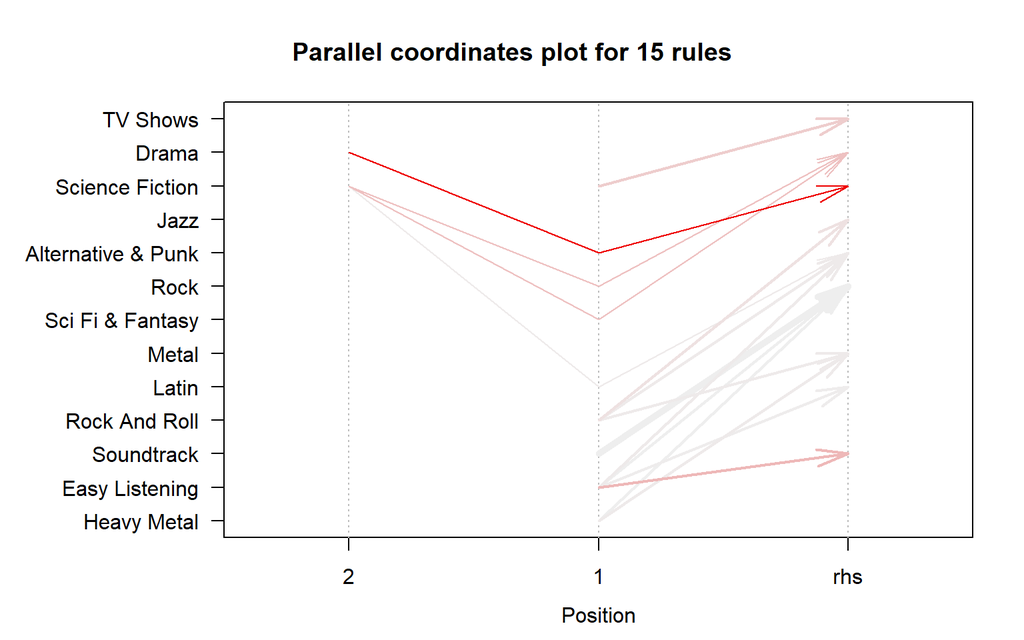

```r
Top10 <- head(mejoresReglas, n = 15, by = "confidence")

plot(Top10, method = "paracoord")
```

## Evaluación frente al objetivo de negocio

Las reglas con **lift > 1** confirman asociaciones reales entre géneros, y las de **mayor confianza** son las directamente accionables para el Criterio de éxito 2.2: cada regla `{A} => {B}` se traduce en un cupón cruzado o en una recomendación dentro de la tienda. Los géneros que aparecen como “detonantes” (posición antecedente con flechas fuertes hacia otros géneros) son los candidatos prioritarios para sembrar campañas de recomendación. De este modo, el resultado técnico queda enlazado con la meta de incrementar el ticket promedio de compra.

# Fase 6 — Despliegue

El despliegue no se materializa en un archivo de exportación, sino en la puesta a disposición del negocio del conocimiento descubierto por el modelo. Las reglas de asociación obtenidas se traducen en acciones concretas alineadas con los objetivos del anteproyecto:

- **Recomendación de venta cruzada.** Cada regla `{A} => {B}` sustenta recomendaciones del tipo “los clientes que compraron este género también compraron…” dentro de la tienda digital.
- **Cupones personalizados por género.** Las reglas de mayor confianza se materializan en cupones cruzados dirigidos a los segmentos identificados, atendiendo directamente al **Criterio de éxito 2.2** del anteproyecto (campañas personalizadas para incrementar el ticket promedio).
- **Visualización para el negocio.** Los resultados se entregan mediante el **dashboard en Tableau Public**, construido sobre el Data Warehouse, que permite a las áreas de marketing y adquisiciones explorar las asociaciones entre géneros para la toma de decisiones.
- **Monitoreo e iteración.** Como cierre del ciclo iterativo de CRISP-DM, el modelo puede re-ejecutarse conforme ingresan nuevas ventas al Data Warehouse, manteniendo vigentes las reglas en el tiempo.